# Euro_Crime_Analysis

Navankur Verma - navankurverma@gmail.com

28/12/2019

## 1. Pull Data

Data Sources are: [Eurostat](https://ec.europa.eu/eurostat/web/crime/data/database) [CSO (Central Statistics Office, Ireland)](https://statbank.cso.ie/px/pxeirestat/Database/eirestat/Annual%20Population%20Estimates/Annual%20Population%20Estimates_statbank.asp?SP=Annual%20Population%20Estimates&Planguage=0)

```r
crime <- import("crim_off_cat_1_Data.csv",setclass = "tibble")

# There are two ways to pull the imigration data (CSO):
# 1. Use utility on the web link to downlad csv file of selected columns
# 2. Download .px file from CSO link and using PC-Axis software convert it to csv and then import it into R

#1.
imig <- import("20191224185114590075PEA1504147693656.csv",setclass = "tibble", skip = 2)
imig <- t(imig)                    #transpose
colnames(imig) <- imig[1,]         #Giving colnames from the 1st row
imig<-as_tibble(imig)              #Converting matrix imig2 to a tibble
imig<-imig[-1,]                    #Removing 1st row as info is now in colnames
colnames(imig)[1] <- "TIME"        #Setting colname of 1st col to TIME
imig <- lapply(imig,as.numeric)    #Converting each column to numeric
imig <- as_tibble(imig)            #converting list from lapply to tibble
imig$TIME <- as.integer(imig$TIME) #Converting Years to integer

#2.
imig <- import("PEA15.csv",setclass = "tibble",skip = 2)
colnames(imig)[1] <- "TIME"                                #Setting colname of 1st col to TIME
imig[,c(2,3,5,6)] <- lapply(imig[,c(2,3,5,6)],as.numeric)  #Converting required columns to numeric
```

## 2. Check Data

```r
#Structure ->
str(crime)
```

```
## tibble [5,330 x 6] (S3: tbl_df/tbl/data.frame)
##  $ TIME              : int [1:5330] 2008 2008 2008 2008 2008 2008 2008 2008 2008 2008 ...
##  $ GEO               : chr [1:5330] "Belgium" "Belgium" "Belgium" "Belgium" ...
##  $ ICCS              : chr [1:5330] "Intentional homicide" "Attempted intentional homicide" "Assault" "Kidnapping" ...
##  $ UNIT              : chr [1:5330] "Per hundred thousand inhabitants" "Per hundred thousand inhabitants" "Per hundred thousand inhabitants" "Per hundred thousand inhabitants" ...
##  $ Value             : chr [1:5330] "1.91" "6.39" "715.43" "9.50" ...
##  $ Flag and Footnotes: logi [1:5330] NA NA NA NA NA NA ...
```

```r
str(imig)
```

```
## tibble [69 x 9] (S3: tbl_df/tbl/data.frame)
##  $ TIME             : int [1:69] 1951 1952 1953 1954 1955 1956 1957 1958 1959 1960 ...
##  $ Annual births    : num [1:69] NA NA NA NA NA NA NA NA NA NA ...
##  $ Annual deaths    : num [1:69] NA NA NA NA NA NA NA NA NA NA ...
##  $ Natural increase : num [1:69] 26.6 27.3 29.1 28.2 24.7 25.6 27.8 25.4 24.9 27.5 ...
##  $ Immigrants       : num [1:69] NA NA NA NA NA NA NA NA NA NA ...
##  $ Emigrants        : num [1:69] NA NA NA NA NA NA NA NA NA NA ...
##  $ Net migration    : num [1:69] -35 -35 -33 -36 -45 -48 -41 -58 -32 -41 ...
##  $ Population change: num [1:69] -8.4 -7.7 -3.9 -7.8 -20.3 -22.4 -13.2 -32.6 -7.1 -13.5 ...
##  $ Population       : num [1:69] 2961 2953 2949 2941 2921 ...
```

```r
# Value in Crime Dataset read as char because as per the data description, those values
# which were not available were filled with ":"
# using gsub to first convert numbers as char (seperated with commas) to numbers as numeric

crime$Value<- as.numeric(gsub(",","",crime$Value))
str(crime)
```

```
## tibble [5,330 x 6] (S3: tbl_df/tbl/data.frame)
##  $ TIME              : int [1:5330] 2008 2008 2008 2008 2008 2008 2008 2008 2008 2008 ...
##  $ GEO               : chr [1:5330] "Belgium" "Belgium" "Belgium" "Belgium" ...
##  $ ICCS              : chr [1:5330] "Intentional homicide" "Attempted intentional homicide" "Assault" "Kidnapping" ...
##  $ UNIT              : chr [1:5330] "Per hundred thousand inhabitants" "Per hundred thousand inhabitants" "Per hundred thousand inhabitants" "Per hundred thousand inhabitants" ...
##  $ Value             : num [1:5330] 1.91 6.39 715.43 9.5 101.05 ...
##  $ Flag and Footnotes: logi [1:5330] NA NA NA NA NA NA ...
```

## 3. Manipulate Data

Dataset can be used as it is without manipulations also. But in the pulled data there are large number of rows in crime data, which we can transform. So ICCS column values are put into different columns with their values corresponding to the crime value in Value column.

```r
crime.wider <- pivot_wider(crime,names_from = "ICCS", values_from = "Value")

crime.wider$All_Theft <-  rowSums(crime.wider[,c('Burglary',
                                                 'Burglary of private residential premises',
                                                 'Theft',
                                                 'Theft of a motorized land vehicle')],
                                  na.rm = TRUE)
# Keeping only required columns
crime.sub <- subset.data.frame(crime.wider, select = -c(3:4,13:16))

str(crime.sub)
```

```
## tibble [410 x 12] (S3: tbl_df/tbl/data.frame)
##  $ TIME                                                  : int [1:410] 2008 2008 2008 2008 2008 2008 2008 2008 2008 2008 ...
##  $ GEO                                                   : chr [1:410] "Belgium" "Bulgaria" "Czechia" "Denmark" ...
##  $ Intentional homicide                                  : num [1:410] 1.91 2.29 1.09 0.96 0.8 6.28 1.14 1.29 0.89 1.6 ...
##  $ Attempted intentional homicide                        : num [1:410] 6.39 0.8 0.86 3.59 1.96 1.49 0.24 1.48 1.94 1.66 ...
##  $ Assault                                               : num [1:410] 715.4 42.8 52.2 30.4 630.6 ...
##  $ Kidnapping                                            : num [1:410] 9.5 1.69 0.15 NA 2.26 0.15 1.3 0.27 0.52 3.24 ...
##  $ Sexual violence                                       : num [1:410] 101.05 9.96 16.24 33.09 69.07 ...
##  $ Rape                                                  : num [1:410] 30.29 3.48 5.11 17.81 8.87 ...
##  $ Sexual assault                                        : num [1:410] 70.76 6.48 11.13 15.29 60.2 ...
##  $ Robbery                                               : num [1:410] 214.5 38.1 44.9 62.1 60.7 ...
##  $ Unlawful acts involving controlled drugs or precursors: num [1:410] 139.2 38 27.2 370 291.9 ...
##  $ All_Theft                                             : num [1:410] 3998 983 2300 8224 3212 ...
```

```r
#creating another dataset which will also contain a column having Total offences for each country in each year
crime.total <- crime.sub
crime.total$Totals <- rowSums(crime.sub[,3:length(crime.sub)],na.rm = TRUE)

#Renaming some names which were quite large
crime.total[grep("Germany",crime.total$GEO),2] <- "Germany"
crime.total[grep("Kosovo",crime.total$GEO),2] <- "Kosovo"
```

## 4. Analysis on Data

Country which had highest number of offences in a year from 2008-2017:

```r
knitr::kable(crime.sub[order(rowSums(crime.sub[,c(3:ncol(crime.sub))],na.rm = TRUE),decreasing = TRUE)[1],])
```

| TIME | GEO | Intentional homicide | Attempted intentional homicide | Assault | Kidnapping | Sexual violence | Rape | Sexual assault | Robbery | Unlawful acts involving controlled drugs or precursors | All_Theft |
| --- | --- | --- | --- | --- | --- | --- | --- | --- | --- | --- | --- |
| 2009 | Denmark | 1.01 | 3.77 | 29.08 | NA | 30.32 | 15.93 | 14.39 | 72.65 | 347.6 | 8621 |

Denamrk in 2009 recorded the highest number of offences in a year among all the EU countries.

Highest number of total offences in each year:

```r
a <- aggregate(crime.total$Totals,list(crime.total$TIME),max,na.rm= TRUE)
yearwisemax <- merge(crime.total,a,by.x = 'Totals', by.y = 'x')
knitr::kable(yearwisemax[order(yearwisemax$TIME),c(1:3)])
```

|  | Totals | TIME | GEO |
| --- | --- | --- | --- |
| 9 | 8757.00 | 2008 | Denmark |
| 10 | 9135.75 | 2009 | Denmark |
| 8 | 8689.99 | 2010 | Denmark |
| 7 | 8612.42 | 2011 | Denmark |
| 6 | 8108.56 | 2012 | Denmark |
| 5 | 7839.77 | 2013 | Denmark |
| 4 | 7254.61 | 2014 | Denmark |
| 3 | 6974.96 | 2015 | Sweden |
| 2 | 6683.56 | 2016 | Sweden |
| 1 | 6549.83 | 2017 | Sweden |

There has been reduction in highest number of total offences over the period of 2008-2017, with Denmark being worst till 2014 and Sweden from 2015.

## 5. Visualizing the data

Plotting each offence for each country in each year from 2008-2017:

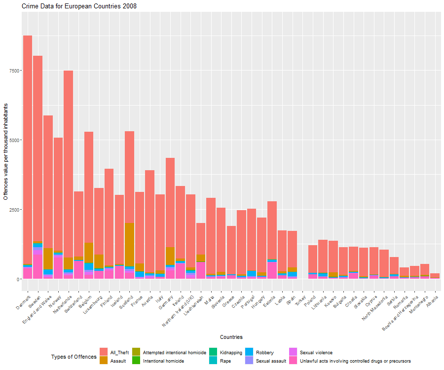

```r
#Converting original dataframe into dataframe with 3 columns
#viz, Country, Type of Offence and Value

crime.longsub <- pivot_longer(crime.sub, cols = 3:12,names_to = "ICCS", values_to = "Values")

#Removing NA rows, as that will cause discrepancy in plots
#Note : Not deleting full country rows but only those combinations of Country-Type of Offence for which no values are present
y <- subset.data.frame(crime.longsub,complete.cases(crime.longsub))
y[grep("Germany",y$GEO),2] <- "Germany"
y[grep("Kosovo",y$GEO),2] <- "Kosovo"

#Plotting the graph
p1 <- ggplot(y,aes(fill = y$ICCS, y = y$Values, x = reorder(y$GEO, -y$Values))) +
  geom_bar(position = "stack", stat = "identity") +
  theme(axis.text.x = element_text(angle = 45, hjust = 1,vjust = 1),
        legend.position = "bottom" ) +
  labs(fill = "Types of Offences", y = "Offences value per thousand inhabitants",
       x = "Countries", title = "Crime Data for European Countries {closest_state}") +
  transition_states(y$TIME, transition_length = 10, state_length = 1)

animate(p1,  width = 900, height = 750, end_pause = 50, renderer = gifski_renderer("gganimq.gif"))
```

```r
#Still need some work to remove those blank chunks in plot (would happily accept any suggestions)
```

Plotting the total number of offences in order (top 10) for each year:

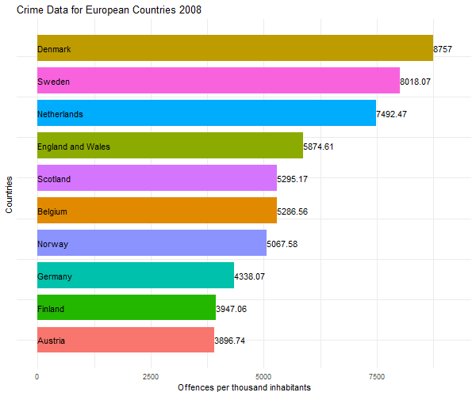

```r
p2 <- crime.total %>%
    group_by(TIME) %>%
    mutate(ordering = rank(-Totals)) %>%
  group_by(GEO) %>%
  filter(ordering <= 10) %>%
  ggplot(aes(-ordering, Totals, fill = GEO)) +
  geom_col(width = 0.8, position = "identity") +
  coord_flip() +
  geom_text(aes(-ordering, y=0, label = GEO, hjust=0)) +       #country label
  geom_text(aes(-ordering, y=Totals, label = Totals, hjust=0)) + # value label
  theme_minimal() +
  theme(legend.position = "none",axis.text.y=element_blank(), axis.ticks.y = element_blank()) +
  labs(y = "Offences per thousand inhabitants",
       x = "Countries", title = "Crime Data for European Countries {closest_state}") +
  transition_states(TIME, transition_length = 10, state_length = 14, wrap = FALSE) +
  ease_aes("sine-in-out")

animate(p2, fps = 20, width = 600, height = 500,nframes = 300, end_pause = 30, start_pause = 30, renderer = gifski_renderer("gganim_top10.gif"))
```

Plotting the total number of offences along with each type of offence in order (top 15) for each year:

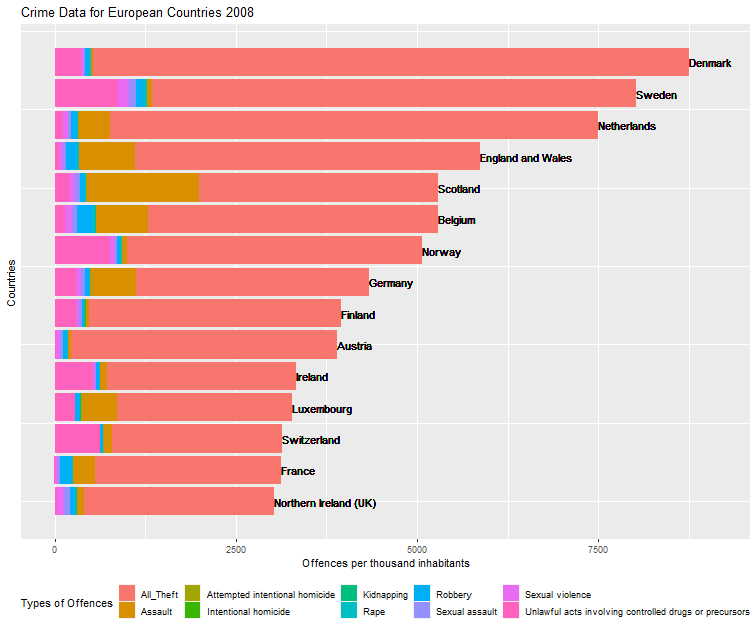

```r
plotdata.total <- crime.total %>%
    group_by(TIME) %>%
    mutate(ordering = rank(-Totals)) %>%
    ungroup()

plotorddatalong <- pivot_longer(plotdata.total,cols = 3:12, names_to = "ICCS", values_to = "Values")

p3 <- plotorddatalong %>%
  group_by(TIME) %>%
  group_by(GEO) %>%
  filter(ordering <= 15) %>%
  ggplot(aes(x = -ordering, y = Values, fill = ICCS)) +
  geom_bar(position = "stack", stat = "identity") +
  coord_flip() +
  geom_text(aes(-ordering,y=Totals,label = GEO, hjust=0)) +
  theme(legend.position = "bottom" , axis.text.y=element_blank(), axis.ticks.y = element_blank())+
  labs(fill = "Types of Offences", y = "Offences per thousand inhabitants",
       x = "Countries", title = "Crime Data for European Countries {closest_state}") +
  transition_states(TIME, transition_length = 1, state_length = 5) +
  ease_aes("sine-in-out")

animate(p3,  width = 756, height = 630, end_pause = 50, renderer = gifski_renderer("gganimtest.gif"))
```

## 6. Analysis on Ireland Data (work in progress)

```r
crime.ireland <- crime.sub[crime.sub$GEO == "Ireland",]
crime.ireland
```

```
## # A tibble: 10 x 12
##     TIME GEO   `Intentional ho~ `Attempted inte~ Assault Kidnapping
##    <int> <chr>            <dbl>            <dbl>   <dbl>      <dbl>
##  1  2008 Irel~             1.14             0.24    86.2       1.3
##  2  2009 Irel~             1.17             0.15    82.2       1.85
##  3  2010 Irel~             1.21             0.15    80.9       1.8
##  4  2011 Irel~             0.92             0.17    77.5       1.68
##  5  2012 Irel~             1.13             0.19    70.1       1.41
##  6  2013 Irel~             1.11             0.28    66.9       1.74
##  7  2014 Irel~             1.15             0.33    68.2       1.3
##  8  2015 Irel~             0.66             0.28    75.0       1.97
##  9  2016 Irel~             0.78             0.51    76.0       1.57
## 10  2017 Irel~             0.86             0.27    84.6       1.59
## # ... with 6 more variables: `Sexual violence` <dbl>, Rape <dbl>, `Sexual
## #   assault` <dbl>, Robbery <dbl>, `Unlawful acts involving controlled drugs or
## #   precursors` <dbl>, All_Theft <dbl>
```

```r
crime.ireland2 <- pivot_longer(crime.ireland, cols = 3:12,names_to = "ICCS", values_to = "Values")
str(crime.ireland2)
```

```
## tibble [100 x 4] (S3: tbl_df/tbl/data.frame)
##  $ TIME  : int [1:100] 2008 2008 2008 2008 2008 2008 2008 2008 2008 2008 ...
##  $ GEO   : chr [1:100] "Ireland" "Ireland" "Ireland" "Ireland" ...
##  $ ICCS  : chr [1:100] "Intentional homicide" "Attempted intentional homicide" "Assault" "Kidnapping" ...
##  $ Values: num [1:100] 1.14 0.24 86.2 1.3 26.91 ...
```

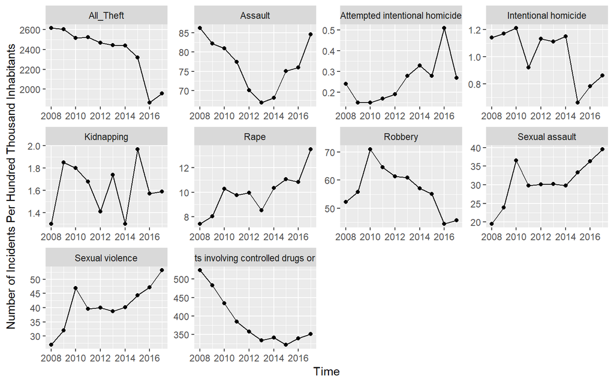

```r
ggplot(crime.ireland2,aes(TIME,Values)) +
  geom_line() +
  geom_point() +
  facet_wrap(~ICCS,scales = "free") +
  scale_x_continuous(breaks = seq(2006,2018,2)) +
  labs(x= "Time", y = "Number of Incidents Per Hundred Thousand Inhabitants")
```

```r
imig10yr <- imig[imig$TIME >= 2008 & imig$TIME <= 2017,]

crime.ireland$Immigrants <- imig10yr$Immigrants

cor(crime.ireland[,c(3:12)], crime.ireland$Immigrants)
```

```
##                                                              [,1]
## Intentional homicide                                   -0.2243421
## Attempted intentional homicide                          0.3692720
## Assault                                                 0.4773286
## Kidnapping                                             -0.3676157
## Sexual violence                                        -0.3530245
## Rape                                                   -0.1433708
## Sexual assault                                         -0.4040114
## Robbery                                                -0.7805264
## Unlawful acts involving controlled drugs or precursors  0.3526378
## All_Theft                                              -0.2079925
```

```r
#corrplot::corrplot.mixed(cor(final[,3:12]))

#pairs(final[,2:12])
```